# LoL AI Project

Amel

Steps:

1. Fetch the data sets.
2. Inspect and Clean them.
3. EDA
4. Train models
5. Evaluate each model performance using the development set

```r
lol2019spr <- read_xlsx("C:/Users/Lenovo/Desktop/all in one/amel/grad studies/Northeastern University/Data Science/Spring 2019/CS 5100 Foundations of AI/project/lol/2019-spring-match-data-OraclesElixir-2019-03-27.xlsx")
lol2018wrld <- read_xlsx("C:/Users/Lenovo/Desktop/all in one/amel/grad studies/Northeastern University/Data Science/Spring 2019/CS 5100 Foundations of AI/project/lol/2018-worlds-match-data-OraclesElixir-2018-11-03.xlsx")
lol2018spr <- read_xlsx("C:/Users/Lenovo/Desktop/all in one/amel/grad studies/Northeastern University/Data Science/Spring 2019/CS 5100 Foundations of AI/project/lol/2018-spring-match-data-OraclesElixir-2018-05-20.xlsx")
lol2018sum <- read_xlsx("C:/Users/Lenovo/Desktop/all in one/amel/grad studies/Northeastern University/Data Science/Spring 2019/CS 5100 Foundations of AI/project/lol/2018 summer match data OraclesElixir 2018-09-27.xlsx")
lol2017 <- read_xlsx("C:/Users/Lenovo/Desktop/all in one/amel/grad studies/Northeastern University/Data Science/Spring 2019/CS 5100 Foundations of AI/project/lol/2017matchdataOraclesElixir.xlsx")
#lol2016 <- read_xlsx("C:/Users/Lenovo/Desktop/all in one/amel/grad studies/Northeastern University/Data Science/Spring 2019/CS 5100 Foundations of AI/project/lol/2016 complete match data OraclesElixir 2018-12-18.xlsx")
```

```r
overview <- function(data) {
  str(data)
  #summary(data)
}
```

```r
plot <- function(data) {
  for(var in names(data)) {
    if(is.numeric(data[[var]])==TRUE) {
      ggplot(data, aes_string(x=var)) + geom_histogram()
    }
    else {
      ggplot(data, aes_string(x=var)) + geom_bar()
    }
  }
}
```

```r
overview(lol2019spr)
```

```r
lol2019spr <- lol2019spr %>% mutate(result = ifelse(result==1, 1, 0))
lol2019spr %>% group_by(result) %>% count()
ggplot(data=lol2019spr, aes(x=teamkills, y=totalgold, color=result==1)) + geom_jitter(alpha = 0.2)
```

[output not shown]

# Transform the data set

We shall set 80% from the 2017 and 2018 match data sets as the training set, the other 20% as the development set; while, the 2019 match data as the test set. Furthermore, we shall include in our analysis only those complete cases, (i.e., observations without missing values.

```r
#LOL 2017 and 2018 data for training and dev sets
lol_data <- rbind(lol2017, lol2018spr, lol2018sum, lol2018wrld)

#Test set
lol_test <- lol2019spr

remove(lol2017, lol2018spr, lol2018sum, lol2018wrld, lol2019spr)


#Note, we are excluding the LOL 2016 data set because of missing variables
```

```r
#We shall filter out non-unique gameids in some leagues
lol_transform <- lol_data %>% filter(!(is.na(gameid) & league=="LPL"),
                                     !(gameid=="1002620109" & league=="NALCS"),
                                      !(gameid=="770284" & league=="TCL")) %>%
  filter(position=="Team") #We shall do team analysis

#We shall extract the total gold earned from each game post the 15 min mark,
#and then join it with the dataset again to extract gold difference post 15 mins.
#This will be our mid to late game gold difference.
summaries <- lol_transform %>% group_by(gameid, league) %>%
  mutate(goldpost15 = totalgold - goldat15) %>% summarize(lategold = sum(goldpost15))

lol_transform <- lol_transform %>% left_join(summaries, by = c("gameid", "league")) %>%
  mutate(redside = ifelse(side=="Red", 1, 0),
         #subtract gold for destroying the Nexus from the winning team
         totalgold = ifelse(result==1, totalgold-250, totalgold),
         tgoldpost15 = totalgold - goldat15, #team gold post 15 mins
         oppgoldpost15 = lategold - tgoldpost15, #opp gold post 15 mins,
         dgoldpost15 = tgoldpost15 - oppgoldpost15, #gold diff post 15 mins against opponents
         pgoldpost15 = tgoldpost15/oppgoldpost15, #ratio gold post 15 mins against opponent
         plategold = tgoldpost15/lategold, #percent of total gold earned in the late game
         pxplead10 = ifelse(xpat10>oppxpat10, (xpat10-oppxpat10)/oppxpat10, 0),
         pgoldlead15 = ifelse(goldat15>oppgoldat15, (goldat15-oppgoldat15)/oppgoldat15, 0),
         pgoldleadpost15 = ifelse(tgoldpost15>oppgoldpost15,
                                  (tgoldpost15-oppgoldpost15)/oppgoldpost15, 0)) %>%
  select(result, redside, gdat10, xpdat10, gdat15,
         cspm, k, d, a, fb, earnedgpm, dmgtochampsperminute,
         firsttothreetowers, wpm, teambaronkills, teamdragkills,
         pgoldpost15, pxplead10, pgoldlead15, pgoldleadpost15)

#We shall include only those with complete cases (no missing values)
lol_transform <- lol_transform %>% mutate(complete = complete.cases(lol_transform)) %>%
  filter(complete==TRUE) %>% select(-complete)
remove(summaries)
```

```r
#Resample into Train (80%) and Dev (20%)
set.seed(1)
lol_resample <- lol_transform %>%
  resample_partition(c(train = 0.8, dev = 0.2))
lol_train <- as.tibble(lol_resample$train)
lol_dev <- as.tibble(lol_resample$dev)
```

```r
nrow(lol_train) #Entire training set
```

```
## [1] 7475
```

```r
nrow(lol_dev) #Entire dev set
```

```
## [1] 1869
```

# Classification Models

## Logistic Regression

Logistic regression function

```r
logit <- function(formula, data) {
  fit <- glm(formula, family = binomial(link = "logit"), data = data)
  print(summary(fit))
  return(fit)
}
```

```r
formula1 <- result ~ redside + fb + xpdat10 + gdat15 + firsttothreetowers + teambaronkills + teamdragkills
fitlogit1 <- logit(formula1, lol_train)
```

```
##
## Call:
## glm(formula = formula, family = binomial(link = "logit"), data = data)
##
## Deviance Residuals:
##     Min       1Q   Median       3Q      Max
## -5.0229  -0.4160   0.0368   0.5444   2.7039
##
## Coefficients:
##                      Estimate Std. Error z value Pr(>|z|)
## (Intercept)        -2.508e+00  9.563e-02 -26.228  < 2e-16 ***
## redside            -4.179e-01  7.051e-02  -5.927 3.08e-09 ***
## fb                  4.143e-02  7.539e-02   0.550    0.583
## xpdat10             3.901e-05  4.402e-05   0.886    0.375
## gdat15              2.731e-04  2.422e-05  11.276  < 2e-16 ***
## firsttothreetowers  9.521e-01  8.332e-02  11.426  < 2e-16 ***
## teambaronkills      1.941e+00  5.816e-02  33.371  < 2e-16 ***
## teamdragkills       4.089e-01  3.155e-02  12.960  < 2e-16 ***
## ---
## Signif. codes:  0 '***' 0.001 '**' 0.01 '*' 0.05 '.' 0.1 ' ' 1
##
## (Dispersion parameter for binomial family taken to be 1)
##
##     Null deviance: 10362.4  on 7474  degrees of freedom
## Residual deviance:  5344.9  on 7467  degrees of freedom
## AIC: 5360.9
##
## Number of Fisher Scoring iterations: 5
```

```r
as.tibble(fitlogit1$coefficients) %>%
            mutate(vars = names(fitlogit1$coefficients)) %>%
  select(vars, value) %>%
  write_csv("C:/Users/Lenovo/Desktop/fitlogit1.csv", append=TRUE)
```

```r
formula2 <- result ~ redside + fb + pxplead10 + pgoldlead15 + firsttothreetowers + teambaronkills + teamdragkills
fitlogit2 <- logit(formula2, lol_train)
```

```
##
## Call:
## glm(formula = formula, family = binomial(link = "logit"), data = data)
##
## Deviance Residuals:
##     Min       1Q   Median       3Q      Max
## -5.0208  -0.3983   0.0314   0.5383   2.6314
##
## Coefficients:
##                    Estimate Std. Error z value Pr(>|z|)
## (Intercept)        -3.00015    0.08961 -33.478  < 2e-16 ***
## redside            -0.43019    0.07055  -6.097 1.08e-09 ***
## fb                  0.11466    0.07374   1.555     0.12
## pxplead10           2.42298    1.23616   1.960     0.05 *
## pgoldlead15         8.25281    0.79544  10.375  < 2e-16 ***
## firsttothreetowers  1.09242    0.07933  13.770  < 2e-16 ***
## teambaronkills      1.95449    0.05841  33.463  < 2e-16 ***
## teamdragkills       0.43386    0.03146  13.789  < 2e-16 ***
## ---
## Signif. codes:  0 '***' 0.001 '**' 0.01 '*' 0.05 '.' 0.1 ' ' 1
##
## (Dispersion parameter for binomial family taken to be 1)
##
##     Null deviance: 10362.4  on 7474  degrees of freedom
## Residual deviance:  5350.6  on 7467  degrees of freedom
## AIC: 5366.6
##
## Number of Fisher Scoring iterations: 5
```

```r
as.tibble(fitlogit2$coefficients) %>%
            mutate(vars = names(fitlogit2$coefficients)) %>%
  select(vars, value) %>%
  write_csv("C:/Users/Lenovo/Desktop/fitlogit2.csv", append = TRUE)
```

# Regularized Logistic Regression

We shall include a wider set of predictors in our model. Regularization works by shrinking the estimated parameters of the predictors; thereby, reducing the risk of multicollinearity and overfitting.

## L2-penalty or Ridge regularization

One method is ridge regularization. We shall pick a tuned lambda that penalizes the coefficients of the predictors. We do this by performing a 10-fold cross-validation of the training set over a range of lambdas. The lambda that has the lowest cross-valided misclassifcation error shall be our choice for lambda as we evaluate the model on the development set.

```r
#Training set with complete cases only
comp_train <- lol_train %>% select(-gdat10, -xpdat10, -gdat15, -pgoldpost15, -earnedgpm,
                                   -dmgtochampsperminute, -wpm)
```

```r
summary(comp_train)
```

```
##      result          redside            cspm             k
##  Min.   :0.0000   Min.   :0.0000   Min.   :21.24   Min.   : 0.00
##  1st Qu.:0.0000   1st Qu.:0.0000   1st Qu.:30.67   1st Qu.: 6.00
##  Median :1.0000   Median :0.0000   Median :32.58   Median :11.00
##  Mean   :0.5021   Mean   :0.4998   Mean   :32.73   Mean   :11.59
##  3rd Qu.:1.0000   3rd Qu.:1.0000   3rd Qu.:34.68   3rd Qu.:16.00
##  Max.   :1.0000   Max.   :1.0000   Max.   :45.85   Max.   :56.00
##        d               a                fb         firsttothreetowers
##  Min.   : 0.00   Min.   :  0.00   Min.   :0.0000   Min.   :0.0000
##  1st Qu.: 6.00   1st Qu.: 14.00   1st Qu.:0.0000   1st Qu.:0.0000
##  Median :11.00   Median : 26.00   Median :1.0000   Median :1.0000
##  Mean   :11.54   Mean   : 27.52   Mean   :0.5021   Mean   :0.5037
##  3rd Qu.:16.00   3rd Qu.: 39.00   3rd Qu.:1.0000   3rd Qu.:1.0000
##  Max.   :56.00   Max.   :111.00   Max.   :1.0000   Max.   :1.0000
##  teambaronkills   teamdragkills     pxplead10        pgoldlead15
##  Min.   :0.0000   Min.   :0.000   Min.   :0.00000   Min.   :0.0000000
##  1st Qu.:0.0000   1st Qu.:1.000   1st Qu.:0.00000   1st Qu.:0.0000000
##  Median :1.0000   Median :2.000   Median :0.00000   Median :0.0001672
##  Mean   :0.7676   Mean   :1.779   Mean   :0.02238   Mean   :0.0439115
##  3rd Qu.:1.0000   3rd Qu.:3.000   3rd Qu.:0.03513   3rd Qu.:0.0718367
##  Max.   :6.0000   Max.   :8.000   Max.   :0.29321   Max.   :0.5159288
##  pgoldleadpost15
##  Min.   :0.000000
##  1st Qu.:0.000000
##  Median :0.007256
##  Mean   :0.181045
##  3rd Qu.:0.332699
##  Max.   :1.340019
```

```r
predictors_matrix <- comp_train %>% select(-result) %>% as.matrix()
response_matrix <- comp_train %>% select(result) %>% as.matrix()
lambdas <- 10^seq(from=-5, to=5, length.out = 100) #shirnkage parameters for tuning
```

```r
set.seed(1234)

#By default, cv.glmnet performs a 10-fold cross validation
cv_ridge <- cv.glmnet(x=predictors_matrix, y=response_matrix, alpha=0,
                      family = "binomial", lambda=lambdas,
                      type.measure="class", standardize=TRUE)
ridge <- tibble(lambda = cv_ridge$lambda,
                mse_cv = cv_ridge$cvm) %>%
  arrange(mse_cv)
ridge <- ridge[1, ]
print(paste("Tuned lambda: ", ridge[[1]], " CV MSE: ", ridge[[2]]))
```

```
## [1] "Tuned lambda:  0.000102353102189903  CV MSE:  0.0276923076923077"
```

```r
coef(cv_ridge, s="lambda.min")
```

```
## 13 x 1 sparse Matrix of class "dgCMatrix"
##                               1
## (Intercept)        -4.319908888
## redside            -0.247318917
## cspm                0.031172514
## k                   0.203379603
## d                  -0.247111685
## a                   0.041373530
## fb                 -0.009759156
## firsttothreetowers -0.062043106
## teambaronkills      0.455418047
## teamdragkills       0.225703917
## pxplead10           4.699683579
## pgoldlead15         1.212829862
## pgoldleadpost15    34.598035513
```

The tuned lambda is 1.02353110^{-4} with a cross-valided MSE of 0.0276923.

## L1-penalty or Lasso Regularization

Our third method is Lasso regularization. We aim to pick a lambda that has the minimum cross-valided MSE over some range of lambdas. Just as in ridge, we shall perform a 10-fold cross-validation.

```r
set.seed(1234)

#By default, cv.glmnet performs a 10-fold cross validation
cv_lasso <- cv.glmnet(x=predictors_matrix, y=response_matrix, alpha=1,
                      family = "binomial", lambda=lambdas,
                      type.measure="class", standardize=TRUE)
lasso <- tibble(lambda = cv_lasso$lambda,
                mse_cv = cv_lasso$cvm) %>%
  arrange(mse_cv)
lasso <- lasso[1, ]
print(paste("Tuned lambda: ", lasso[[1]], " CV MSE: ", lasso[[2]]))
```

```
## [1] "Tuned lambda:  1e-05  CV MSE:  0.0274247491638796"
```

```r
coef(cv_lasso, s="lambda.min")
```

```
## 13 x 1 sparse Matrix of class "dgCMatrix"
##                              1
## (Intercept)        -4.04067850
## redside            -0.23869149
## cspm                0.01660708
## k                   0.19211218
## d                  -0.23414362
## a                   0.04233949
## fb                  0.04283779
## firsttothreetowers -0.14049035
## teambaronkills      0.35646689
## teamdragkills       0.21173123
## pxplead10           5.39702879
## pgoldlead15         1.76075485
## pgoldleadpost15    46.35488708
```

Our tuned paramater for Lasso is 10^{-5} with a cross-valided MSE, 0.0274247.

## Decision Tree

```r
fitdtree <- tree::tree(result ~ ., data = lol_train %>%
                         mutate(result = as.factor(result),
                                redside = as.factor(redside),
                                firsttothreetowers = as.factor(firsttothreetowers),
                                fb = as.factor(fb)) %>% select(-pgoldpost15))
summary(fitdtree)
```

```
##
## Classification tree:
## tree::tree(formula = result ~ ., data = lol_train %>% mutate(result = as.factor(result),
##     redside = as.factor(redside), firsttothreetowers = as.factor(firsttothreetowers),
##     fb = as.factor(fb)) %>% select(-pgoldpost15))
## Variables actually used in tree construction:
## [1] "pgoldleadpost15" "earnedgpm"
## Number of terminal nodes:  4
## Residual mean deviance:  0.1436 = 1073 / 7471
## Misclassification error rate: 0.02381 = 178 / 7475
```

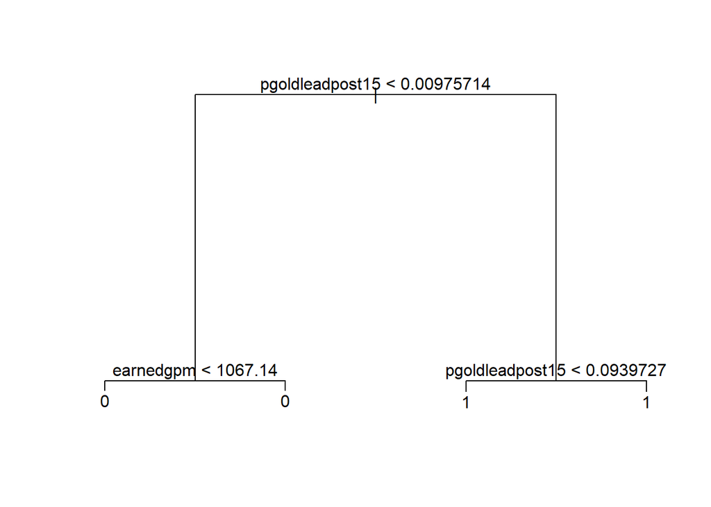

```r
plot(fitdtree)
text(fitdtree, pretty = 0)
```

We shall perform cross-validation and determine the node that has the lowest misclassification error. We shall then prune the tree for cost complexity.

```r
cv_fitdtree <- tree::cv.tree(fitdtree, FUN=prune.misclass)
cv_fitdtree
```

```
## $size
## [1] 4 2 1
##
## $dev
## [1]  181  181 3771
##
## $k
## [1] -Inf    0 3544
##
## $method
## [1] "misclass"
##
## attr(,"class")
## [1] "prune"         "tree.sequence"
```

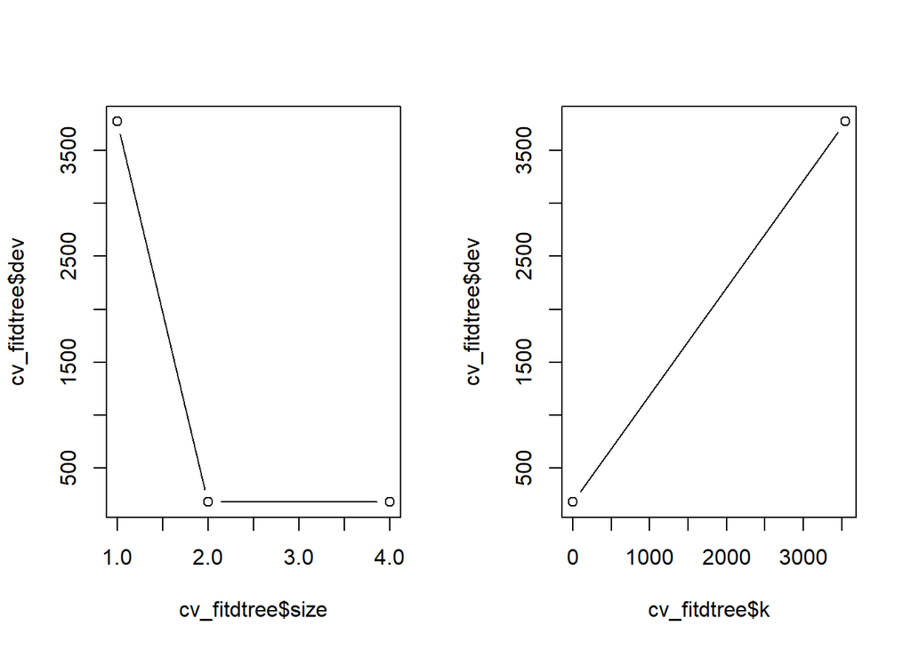

```r
par(mfrow =c(1,2))
plot(cv_fitdtree$size, cv_fitdtree$dev, type="b")
plot(cv_fitdtree$k, cv_fitdtree$dev, type="b")
```

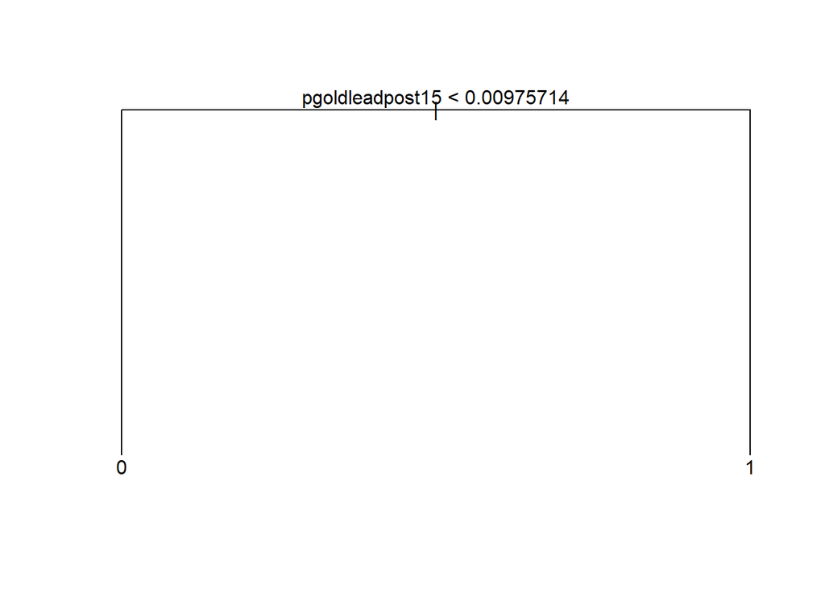

```r
prune_fitdtree <- tree::prune.tree(fitdtree, best = 2)
plot(prune_fitdtree )
text(prune_fitdtree, pretty =0)
```

## Ensemble Methods

### 1. Bootstraping

```r
set.seed (1)
lolrbagging <- randomForest(result ~ .,
                            data = lol_train %>%
                              mutate(result = as.factor(result),
                                     redside = as.factor(redside),
                                     fb = as.factor(fb),
                                     firsttothreetowers = as.factor(firsttothreetowers)) %>%
                              select(-pgoldleadpost15),
                            mtry = ncol(comp_train %>% select(-result)),
                            importance =TRUE, na.action = na.omit)
lolrbagging
```

```
##
## Call:
##  randomForest(formula = result ~ ., data = lol_train %>% mutate(result = as.factor(result),      redside = as.factor(redside), fb = as.factor(fb), firsttothreetowers = as.factor(firsttothreetowers)) %>%      select(-pgoldleadpost15), mtry = ncol(comp_train %>% select(-result)),      importance = …
##                Type of random forest: classification
##                      Number of trees: 500
## No. of variables tried at each split: 12
##
##         OOB estimate of  error rate: 2.23%
## Confusion matrix:
##      0    1 class.error
## 0 3638   84  0.02256851
## 1   83 3670  0.02211564
```

```r
importance(lolrbagging)
```

```
##                                0          1 MeanDecreaseAccuracy
## redside               -2.6044494  0.1257259           -1.8829250
## gdat10                 1.8561191  3.7044378            3.9855906
## xpdat10                2.9417009  7.3935462            5.9626910
## gdat15                 9.4188258  9.6984152           14.0830108
## cspm                   2.7943645  9.7761043            9.3594115
## k                      4.2103250  6.7202718            7.3393418
## d                     20.2820428 14.1317341           22.2629314
## a                      8.6503737 18.4024827           16.5070362
## fb                    -0.8759482  1.6339123            0.4388301
## earnedgpm             16.4458910  7.6444675           17.9200518
## dmgtochampsperminute   3.2305095 17.4823032           15.7356259
## firsttothreetowers     1.0616973  0.7223223            1.3967395
## wpm                    5.4321017 -4.9290645            0.1447820
## teambaronkills        16.6635718 -7.8560509           10.7922585
## teamdragkills          6.6140592  5.4259738            9.3591734
## pgoldpost15          125.6264393 97.3539529          149.3474065
## pxplead10              3.5598632  4.4136611            5.3201110
## pgoldlead15            4.4462454  1.9054616            5.1732769
##                      MeanDecreaseGini
## redside                      1.994598
## gdat10                      13.575468
## xpdat10                     16.946626
## gdat15                      15.881782
## cspm                        23.463527
## k                           17.748030
## d                           40.514846
## a                           43.839055
## fb                           1.990801
## earnedgpm                  657.316751
## dmgtochampsperminute        25.817751
## firsttothreetowers           2.424524
## wpm                         19.599747
## teambaronkills             194.193243
## teamdragkills                9.968038
## pgoldpost15               2637.673977
## pxplead10                    7.829803
## pgoldlead15                  6.145217
```

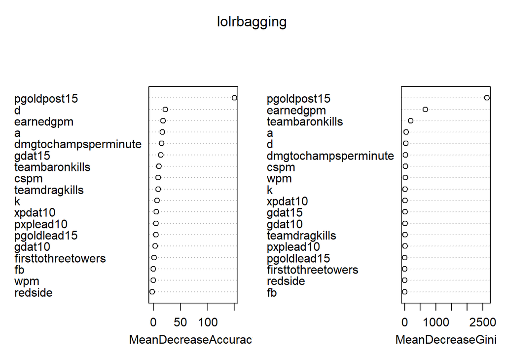

```r
varImpPlot(lolrbagging)
```

### 2. Random Forest

```r
set.seed (1)
lolrforest <- randomForest::randomForest(result ~ ., data = lol_train  %>%
                              mutate(result = as.factor(result),
                                     redside = as.factor(redside),
                                     fb = as.factor(fb),
                                     firsttothreetowers = as.factor(firsttothreetowers)) %>%
                                select(-pgoldpost15, -gdat15, -xpdat10),
                         importance =TRUE, na.action = na.omit)
lolrforest
```

```
##
## Call:
##  randomForest(formula = result ~ ., data = lol_train %>% mutate(result = as.factor(result),      redside = as.factor(redside), fb = as.factor(fb), firsttothreetowers = as.factor(firsttothreetowers)) %>%      select(-pgoldpost15, -gdat15, -xpdat10), importance = TRUE,      na.action = na.omit)
##                Type of random forest: classification
##                      Number of trees: 500
## No. of variables tried at each split: 4
##
##         OOB estimate of  error rate: 2.29%
## Confusion matrix:
##      0    1 class.error
## 0 3643   79  0.02122515
## 1   92 3661  0.02451372
```

```r
imptforest <- tibble(var = attr(importance(lolrforest), which = "dimnames")[[1]],
                gini = importance(lolrforest)[, 4]) %>% arrange(-gini)
imptforest
```

```
## # A tibble: 16 x 2
##    var                     gini
##    <chr>                  <dbl>
##  1 pgoldleadpost15      1395.
##  2 earnedgpm             862.
##  3 teambaronkills        471.
##  4 d                     291.
##  5 a                     234.
##  6 k                     167.
##  7 teamdragkills          76.0
##  8 firsttothreetowers     57.7
##  9 dmgtochampsperminute   42.7
## 10 cspm                   32.6
## 11 pgoldlead15            32.1
## 12 wpm                    26.3
## 13 gdat10                 25.5
## 14 pxplead10              15.4
## 15 fb                      3.92
## 16 redside                 3.48
```

```r
imptforest %>%  write_csv("C:/Users/Lenovo/Desktop/rforest.csv")
```

# Performance of the models on the Development set

```r
#Accuracy function
accuracy <- function(data) {
  accuracy <- data %>%
    mutate(correct = ifelse(result==pred, 1, 0)) %>%
    summarize(sum(correct)/n())
  return(accuracy[[1]])
}
```

## 1. Accuracy of Logit on the dev set

```r
#Predictions of Logit model 1
formula1
```

```
## result ~ redside + fb + xpdat10 + gdat15 + firsttothreetowers +
##     teambaronkills + teamdragkills
```

```r
dev_logit1 <- lol_dev %>%
  mutate(prob = predict(fitlogit1, newdata=lol_dev, type="response"),
         pred = ifelse(prob>=0.5, 1, 0)
  ) %>% select(result, pred)

#Accuracy on Dev Set
accuracy(dev_logit1)
```

```
## [1] 0.8715891
```

```r
#Predictions of Logit model 2
formula2
```

```
## result ~ redside + fb + pxplead10 + pgoldlead15 + firsttothreetowers +
##     teambaronkills + teamdragkills
```

```r
dev_logit2 <- lol_dev %>%
  mutate(prob = predict(fitlogit2, newdata=lol_dev, type="response"),
         pred = ifelse(prob>=0.5, 1, 0)
  ) %>% select(result, pred)

#Accuracy on Dev Set
accuracy(dev_logit2)
```

```
## [1] 0.8742643
```

## 2. Accuracy of L1 (Lasso) Regularized Logit on the dev set

```r
#Predictions on Dev set
x <- lol_dev %>% select(-result, -gdat10, -xpdat10, -gdat15, -pgoldpost15,
                        -wpm, -dmgtochampsperminute, -earnedgpm) %>%
  as.matrix()
pred_lasso <- predict(cv_lasso, s = "lambda.min",
                          newx = x, type="class")
dev_lasso <- lol_dev %>%
  mutate(pred = as.numeric(pred_lasso)) %>%
  select(result, pred)
remove(x, pred_lasso)
```

```r
#Accuracy on Dev Set
accuracy(dev_lasso)
```

```
## [1] 0.9673622
```

## 3. Accuracy of Decision tree on the dev set

```r
#Predictions on dev set
pred_dtree <- as.tibble(predict(prune_fitdtree, newdata = (lol_dev) %>%
                         mutate(result = as.factor(result),
                                redside = as.factor(redside),
                                firsttothreetowers = as.factor(firsttothreetowers),
                                fb = as.factor(fb))))
dev_dtree <- lol_dev %>% mutate(
  pred = ifelse(pred_dtree$`1`>pred_dtree$`0`, 1, 0)) %>%
  select(result, pred)
remove(pred_dtree)
```

```r
#Accuracy on Dev Set
accuracy(dev_dtree)
```

```
## [1] 0.9689674
```

## 4. Accuracy of Random Forest on the dev set

```r
#Predictions on dev set
pred_rforest <- predict(lolrforest,
                                   newdata = lol_dev %>% mutate(result = as.factor(result),
                                     redside = as.factor(redside),
                                     fb = as.factor(fb),
                                     firsttothreetowers = as.factor(firsttothreetowers)))
dev_rforest <- lol_dev %>%
  mutate(pred = pred_rforest) %>%
           select(result, pred)
remove(pred_rforest)
```

```r
#Accuracy on Dev Set
accuracy(dev_rforest)
```

```
## [1] 0.9716426
```

References:

1. Anybody else feels like the side of the map matters? A LOL community forum. Retrieved online: https://boards.na.leagueoflegends.com/en/c/gameplay-balance/EiU910cH-anybody-else-feel-like-the-side-of-the-map-matters